#### **DATOS DEL ENCARGO:**

| TERMINOS | DATOS |
| --- | --- |
| EXPEDIENTE: | 21000001 |
| TIPOLOGIA: | VIVIENDA EN EDIFICIO |
| SITUADO: | CALLE VERACRUZ |
| POBLACION: | Galapagar |
| PROVINCIA: | MADRID |
| SOLICITANTE: | FCO JAVIER POLO MARTINEZ |
| ENTIDAD: | PARTICULAR |
| OFICINA: | 12345678910 |
| S/Ref: | AC0001 |
| CONTACTO | PEPE BOTELLA |
| DIRECCION | VERACRUZ 33 |
| MUNICIPIO | Galapagar |
| C. P | 28260 |
| N.I.F | 50717788A |

| DATOS |  |
| --- | --- |
| Tecnico: | Francico Javier Polo Martinez |
| Asociado: | Miembro de la AEVIU |
| Profesion: | Arquitecto Técnico |
| Profesion: | Data Scientist |
| Movil: | 669781152 |
| Correo: | polomartinezjavier@gmail.com |
| Asociacion: | AEVIU |
| Web: | https://www.aeviu.es/ |

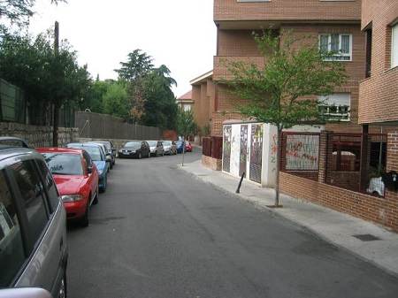

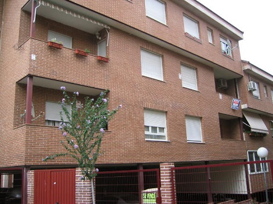

[figure not shown]

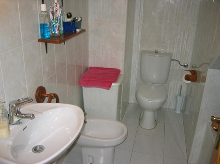

#### **CONSIDERACIONES, OBJETIVO, FINALIDAD DE LA VALORACION Y BASE VALOR:**

> A requerimiento de la propiedad se realiza el presente informe de valoración para determinar el Valor de Mercado de la Vivienda en edificio plurifamiliar con Referencia Catastral 0135606VK2503N0002KM. (Ver contrato de prestación de servicios).

| FINALIDAD/BASE VALOR: |  |
| --- | --- |
| FINALIDAD: | VALOR DE MERCADO |
| BASE VALOR: | VALOR DE MERCADO POR COMPARACION |

**CONSIDERACIONES, VALORADOR, CLIENTE, FINALIDAD Y DIRECTIVA, haz click para expandir**

Concepto

Descripcion

Consideraciones:

- POSICIÓN DEL VALORADOR: Externa al cliente.
- VINCULACIÓN: Los honorarios facturados al cliente por la emisión del presente informe no comprometen la posición de independencia, del valorador.
- DECLARACION EXPRESA: El valorador declaran que no existe elemento alguno que altere su independencia, integridad y objetividad en la realización de la valoración solicitada por el cliente.
- RESPONSABILIDAD ANTE TERCEROS: El presente Informe de Valoración es confidencial para uso exclusivo del cliente, correspondiendo a éste la potestad de permitir su consulta a terceros, respecto de los cuales el valorador deniegan la asunción de responsabilidades.
- RESTRICCION A LA PUBLICACION: Ni la totalidad ni parte de este documento o de alguna de las referencias aquí expuestas deben ser incluidas en ninguna publicación, circular o declaración, ni publicadas en modo alguno sin la aprobación escrita por parte del valorador.
- SUPUESTOS ESPECIALES: En el presente informe no existen supuestos especiales a efectos valorativos.
- INEXISTENCIA DE CONFLICTOS DE INTERES: El valorador confirman la inexistencia de conflictos de interés con el cliente o cualquier otro usuario previsto.

Valorador:

Cliente:

- Nombre: PEPE POLO PEREZ.
- DNI/CIF: 1430335548D.
- Entidad / Por mediación de: DIRECT.

Finalidad:

La finalidad del presente informe es la valoración del inmueble a efectos de **DETERMINAR EL VALOR DE MERCADO**. La validez del presente informe es de 3 meses

Directiva 2014/17/EU (MCD):

Los Estados Miembros de la Unión Europea garantizarán que los valoradores internos y externos que elaboren valoraciones del bien inmueble son profesionales competentes y suficientemente independientes del proceso crediticio de forma que puedan emitir una valoración imparcial y objetiva, que será documentada en un soporte duradero y del cual el prestador conservará una copia.

**EVS 1; Valor de Mercado, haz click para expandir**

Concepto

Descripcion

EVS 1 Valor de Mercado:

El Valor de Mercado es un concepto clave para el establecimiento de una expectativa informada del precio de un bien, neutral entre comprador y vendedor. La naturaleza del mercado en el que se determina el valor diferirá de acuerdo al sujeto dea transacción, mientras que las condiciones del mercado variarán con el equilibrio cambiante de oferta y demanda, conocimiento, moda, regulación, expectativas, condiciones de crédito, expectativas de beneficio y otras circunstancias. Definición del Reglamento de requisitos de capital de la UE: **Cuantía estimada por la que el bien debería intercambiarse, en la fecha de valoración, entre un comprador dispuesto a comprar y un vendedor dispuesto a vender, en una transacción libre, tras una comercialización adecuada en la que las partes hayan actuado con conocimiento de causa, de manera prudente y sin coacción**. EVS 1 considera el Valor de Mercado en el contexto de los bienes inmuebles, incluyendo intereses y derechos sobre terrenos y edificaciones. EVS 1 considera específicamente la aplicación de Valor de Mercado a:

- Bienes raíces y derechos reales relacionados que son menos homogéneos que otra clase de activo y para los cuales esas condiciones de mercado instantáneas, de liquidez e informadas raramente existen pero para los cuales con frecuencia es necesario identificar valores de mercado;
- Que son comercializables, es decir que puedan definirse legal y físicamente como disponibles;
- Es así para asesorar tanto el valor que podría esperarse que será pagado por la posesión del inmueble y la renta que podría ser pagada para alquilarlo. El Valor de Mercado es el valor estimado de un bien y por tanto excluye costes adicionales asociados a la venta o adquisición así como cualquier impuesto sobre la transacción. En Particular, el Valor de Mercado será el valor antes de los impuestos que puedan ser aplicación a cualquier transacción real sobre el bien inmueble valorado.

**MUNICIPIO Y ENTORNO, haz click para expandir**

Concepto

Descripcion

Municipio:

Galapagar es un municipio del noroeste de la Comunidad de Madrid (España), a 33 kilómetros de la capital de España. Se extiende sobre una superficie de 65 km². Limita con Collado Villalba, Colmenarejo, Torrelodones, Las Rozas de Madrid, El Escorial, San Lorenzo de El Escorial, Villanueva del Pardillo, Hoyo de Manzanares, Moralzarzal y Guadarrama. Está ubicado en las estribaciones de la sierra de Guadarrama. Dentro del municipio se halla parte del Parque Regional del curso medio del río Guadarrama y su entorno, caracterizado por el predominio del bosque mediterráneo y de ribera, así como por la existencia de amplias zonas de pastos. Encinas, enebros, fresnos, jaras, quejigos y pinos se cuentan entre las principales especies vegetales del municipio. Galapagar tiene un clima mediterráneo con estaciones más pronunciadas debido a la altitud y la lejanía del mar. Los inviernos son frescos, mientras que los veranos son muy cálidos.

Entorno:

- Entorno de la vivienda a valorar:
- TIPO: Urbano, Promoción situada en el Centro urbano, entre las calles: Saeta y Fuente del Jitano.
- NIVEL DE RENTA: El nivel de renta del entorno es medio.
- RASGOS DE HOMOGENEIDAD: Homogeneidad media; viviendas plurifamiliares con/sin equipamientos comunes.
- ANTIGÜEDAD: La antigüedad del entorno es aproximadamente de treinta años.
- CONSOLIDACIÓN: El grado de consolidación del entorno se estima de un 100%.
- OCUPACIÓN: La ocupación se estima en un 95%.
- USO DOMINANTE: Residencial, primera y segunda vivienda.
- GRADO DE RENOVACIÓN: El grado de renovación se estima en un 20%.

Infraestructuras:

El municipio cuenta con cuatro líneas de autobús, una nocturna, y dos de ellas con cabecera en Madrid, en el Intercambiador de Moncloa. Estas líneas están operadas por la empresa Julián de Castro, S.L. y son:

- Línea 630: Villalba (estación) - Galapagar - Colmenarejo - Valdemorillo.
- Línea 631: Madrid (Moncloa)-Torrelodones (Colonia)-Galapagar-Colmenarejo
- Línea 633: Majadahonda (hospital)-Torrelodones (Colonia)-Galapagar-Colmenarejo
- Línea 634: Colmenarejo- Galapagar - La Navata
- Línea N904: Madrid (Moncloa)-Torrelodones (colonia)-Galapagar-Colmenarejo

Economia

La economía de Galapagar ha estado tradicionalmente orientada hacia el sector primario, particularmente la ganadería. El aumento demográfico registrado en los últimos lustros ha conducido a un creciente peso del sector de los servicios (comercio, banca, etc.). Desde finales de la década de 1990, el auge de la actividad en el sector de la construcción se ha saldado con la urbanización de numerosas hectáreas de suelo municipal, con polémicas recalificaciones que han contado con el visto bueno de los sucesivos gobiernos locales.

**EVOLUCION Y DISTRIBUCION DE LA POBLACION, haz click para expandir**

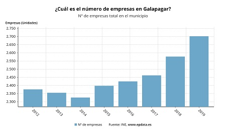

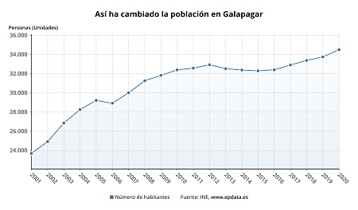

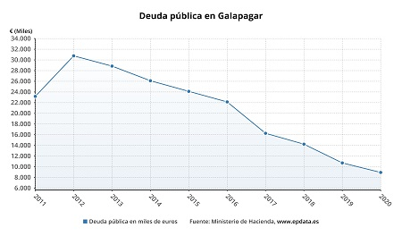

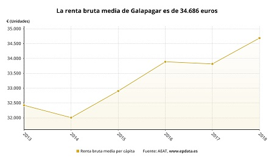

#### **PLANOS DE SITUACION Y LOCALIZACION:**

> Se realiza el plano de localización, situación y del entorno a apartir de Leaflet para mapas interactivos, el cual se puede desplazar vertical y horizontalmente, zoom y se marca la situación del inmueble a valorar.

[interactive chart not shown]

> Los planos se han obtenido de la consulta efectuada ante la Sede Electrónica de catastro a partir de la referencia catastral facilitada por la propiedad. Esta informacion puede ser bien el IBI (Impuesto de Bienes Inmuebles), o la Documentación Registral (Nota Simple o Escritura de la Propiedad)

[interactive chart not shown]

**DATOS REGISTRALES:, haz click para expandir**

El número de finca señalado en el cuadro de valoración corresponden con el número de finca registral. Se valora el 100% de participación de cada una de las fincas registrales.

TITULARES

| Nombre | N | Apellidos | A | NIF | Propiedad | Derecho |
| --- | --- | --- | --- | --- | --- | --- |
| FRANCISCO | JAVIER | POLO | MARTINEZ | 00012311Q | 100% | Pleno Dominio |

Datos Registrales

[output not shown]

**NOTA SIMPLE / ESCRITURA DE LA PROPIEDAD, haz click para expandir**

[figure not shown]

[figure not shown]

**DOCUMENTACIÓN UTILIZADA Y COMPROBACIONES REALIZADA:o, haz click para expandir**

- **VISITA AL INMUEBLE**.

  Documentación registral: Nota simple del Registro de la Propiedad con fecha de emisión **05/08/2017.**  
  Documentación de la Sede Electrónica del Catastro  
  Planos del inmueble con escala gráfica.
- **COMPROBACIONES REALIZADAS.**

  Localización del inmueble e inspección ocular del interior.  
  Superficies.  
  Características físicas identificativas.  
  Servidumbres visibles.  
  Estado de construcción o conservación aparente.  
  Descripción registral.  
  Estado de ocupación.  
  Uso o explotación del inmueble.  
  Régimen de protección pública.  
  Protección del patrimonio arquitectónico.  
  Adecuación al planeamiento urbanístico vigente.  
  Consulta en página virtual de la Sede Electrónica del Catastro

#### **EDIFICIO**

> Se trata de una vivienda en edificio plurifamiliar con ascensor que se desarrolla en cinco plantas sobre rasante destinadas a vivienda con aprovechamiento bajo cubierta, los garajes se localizan en los soportales.

> CALIFICACION DEL TASADOR: Bueno.

| TIPO DE EDIFICACION | EDIFICIO RESIDENCIAL TERMINADO |
| --- | --- |
| Tipologia: | Piso |
| Uso edificio: | Residencial |
| Conservacion: | Media |
| Ubicacion relativa en el municipio: | Media |
| Ubicacion relativa en el barrio | Media |
| Anno de Construccion: | 1999 |
| Antiguedad: | 22 |
| Vida util: | 100 |
| Anno Maximo vida util: | 2099 |
| Anno de Rehabilitacion: | 1999 |
| Zonas Comunes: | Si |
| Acceso Minuesvalidos: | Si |
| Numeros de portales: | 5 |
| Plantas Bajo Rasante: | 0 |
| Plantas Sobre Rasante: | 5 |
| N de ascensores | 1 |
| N de viviendas por planta: | 2 |
| Piscina: | Si |
| Tenis: | No |
| Padel: | No |
| Squash: | No |
| Cancha Polideportiva: | No |
| Zonas Verdes: | Si |
| Zona de juegos infantil: | No |
| Cimentacion: | Zantas Aisladas, Corridas, Hormigon Armado |
| Estructura: | Hormigon Armado |
| Cubierta: | Inclinada con teja como material de cubricion |
| Fachada: | Fabrica de ladrillo cara vista |
| Carpinteria Exterior: | PVC en blanco |
| Acristalamiento: | Tipo climalit |
| Rejas: | No |
| Contraventanas: | No |
| Ligado Explotacion Economica: | No |
| Uso Autorizado Urbanisticamente: | Si |
| Construccion Autorizada: | Si |
| ITE: | No Disponible |
| Ocupacion: | Propietario |
| Arrendado: | No |
| Tipo de Proteccion: | Libre |
| Contaminacion aparente Terreno: | No |
| Contaminacion aparente Ambiental: | No |
| Contaminacion aparente Acustica: | No |
| Contaminacion aparente Constr.: | No |
| Contaminacion aparente Otros: | No |

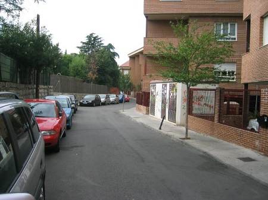

vista exterior

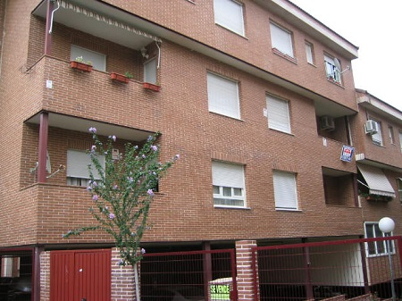

vista exterior

[figure not shown]

vista exterior

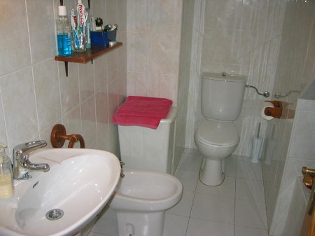

#### **ELEMENTO DE EDIFICIO**

| TIPO DE INMUEBLE | VIVIENDA PLURIFAMILIAR |
| --- | --- |
| Uso registral: | Residencial |
| Uso tasado: | Residencial |
| Tipologia unidad tasada: | VIVIENDA EN EDIFICIO |
| Localizacion Elemento: | Nucleo Urbano |
| Ubicacion relativa en el municipio: | Nivel Medio |
| Ubicacion relativa en el inmueble: | Nivel Medio |
| Ubicacion relativa barrio o zona: | Nivel Medio |
| Orientacion: | No influye en el valor |
| Destino: | Primera Residencia |
| Plantas bajo rasante: | 0 |
| Plantas sobre rasante: | 1 |
| Posicion en Edificio: | exterior |
| Dormitorios: | 3 |
| Baños: | 2 |
| Cocina equipada: | Si |
| Lavadero: | Si |
| Terrazas: | 1 |
| Armarios empotrados: | Si |
| Tendedero: | Si |
| Apartamento turistico: | No |
| Calidad Global: | Media |
| Carpintería interior: | Madera chapada en pino barnizada |
| Puerta de acceso: | Blindada |
| Agua caliente sanitaria: | Caldera individual por gas natural |
| Calefaccion: | Caldera individual por gas natural |
| Aire Acondicionado: | No |
| Sistema de alarma: | No |
| Solado Salon-Comedor: | Tarima |
| Solado Cocina: | Gres porcelanico |
| Solado Dormitorios: | Tarima |
| Solado Bannos: | Gres porcelanico |
| Paramentos verticales Salon-Comedor: | Pintura lisa |
| Paramentos verticales Cocina: | Gres normal |
| Paramentos verticales Dormitorios: | Pintura lisa |
| Paramentos verticales Bannos: | Gres normal |
| Techo Salon-Comedor: | Pintura lisa |
| Techo verticales Cocina: | Pintura lisa |
| Techo verticales Dormitorios: | Pintura lisa |
| Techo verticales Bannos: | Pintura lisa |
| Latitud: | 40.57452 |
| Longuitud: | -4.002505 |

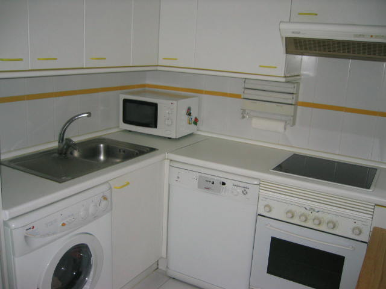

[figure not shown]

vista exterior

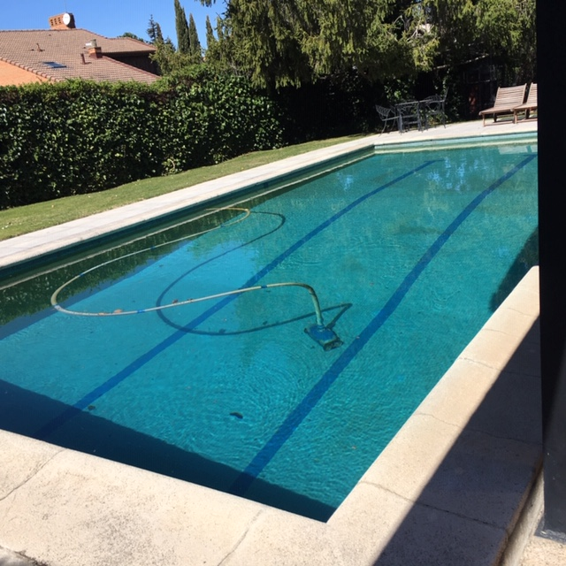

vista exterior

[figure not shown]

#### **CUADRO DE SUPERFICIES**

Concepto

Descripcion

Área de planta interna (IFA):

- El IFA de cada piso debe calcularse entre las superficies internas de las paredes externas del edificio. El IFA es el área bruta del piso (GFA) después de deducir el área de construcción exterior (ECA).
- Las medidas deben tomarse a una altura especificada sobre el suelo. Cuando los techos sean inclinados, los valoradores deben explicar cómo han medido el área.

Área de planta neta (NFA):

- Ésta es el área utilizable que ofrecen todos los pisos dentro de un edificio en las siguientes bases.
- Cada piso debe medirse en todos los niveles entre las superficies internas de las paredes externas del edificio. El NFA es el área de planta interno (IFA) después de deducir el área de construcción interior (ICA).
- Las medidas deben tomarse a una altura especificada sobre el suelo. Cuando los techos sean inclinados, se deben especificar las reglas de medición.
- Las siguientes áreas de cada piso deben excluirse del cálculo.
- Paredes estructurales internas.
- Ventilación vertical, cableado o conductos de tuberías y columnas estructurales (por lo general, solo se excluyen los elementos de más de un metro cuadrado de superficie, pero pueden existir prácticas diferentes entre países).
- Escaleras y pozos de ascensor.
- Cuartos de motores de ascensores, cuartos de tanques (distintos de los utilizados para procesos), cuartos de transformadores, áreas de alta y baja tensión.
- Espacio ocupado por aparatos permanentes de aire acondicionado, calefacción o refrigeración y conductos de superficie que inutilizan el espacio, teniendo en cuenta la finalidad para la que se dice que se utiliza. Esto no se aplica a los aparatos instalados por el inquilino o en su nombre o utilizados en el edificio para fines especiales, como uso de ordenadores, procesamiento o fabricación.
- Al calcular esta área para edificios de oficinas, se deben excluir las siguientes áreas de cada piso:
- Áreas reservadas como espacio público para las calles y no utilizadas exclusivamente por los ocupantes del edificio. Nota: Las áreas comunes adicionales que pueden crearse mediante la subdivisión de un solo piso para acomodar a más de un inquilino deben incluirse en los cálculos).
- Aquellas áreas reservadas para la provisión de instalaciones o servicios al edificio que no sean de uso exclusivo de los ocupantes del edificio.

| SUPERFICIE REGISTRAL | m2 |
| --- | --- |
| Planta sotano: | 0.0 |
| Planta baja: | 90.5 |
| Planta alta: | 0.0 |
| Planta Bajo Cubierta: | 0.0 |
| Cuerpo constructivo indpte: | 0.0 |
| Terraza al 50 % | 0.0 |
| Terraza al 100 % (plurifamiliares) | 0.0 |
| Total superficie registral: | 90.5 |
| Superficies utiles comprobadas: |  |
| Planta sotano: | 0.0 |
| Planta baja: | 70.0 |
| Planta alta: | 0.0 |
| Planta Bajo Cubierta: | 0.0 |
| Cuerpo constructivo indpte: | 0.0 |
| Terraza al 50 % | 3.0 |
| Terraza al 100 % (plurifamiliares) | 0.0 |
| Total superficie util comprobada: | 73.0 |
| Superficies construidas comprobadas: |  |
| Planta sotano: | 0.0 |
| Planta baja: | 82.5 |
| Planta alta: | 0.0 |
| Planta Bajo Cubierta: | 0.0 |
| Cuerpo constructivo: | 0.0 |
| Terraza al 50 % | 3.0 |
| Terraza al 100 % (plurifamiliares) | 0.0 |
| Total de superficie construida comprobada: | 85.5 |
| Superficie catastral: | 86.0 |

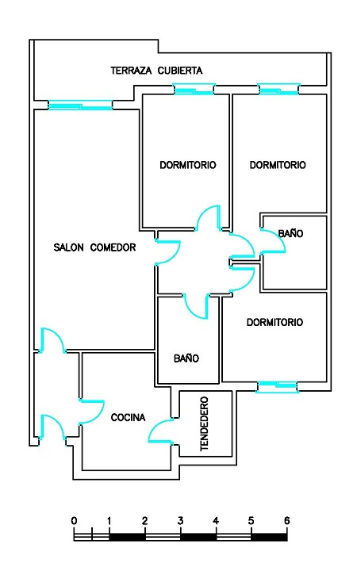

**CUADRO RESUMEN DE SUPERFICIES:**

| SUPERFICIES | m2 |
| --- | --- |
| Superficie Parcela Registral: | 0.0 |
| Superficie Parcela Catastral: | 0.0 |
| Total superficie registral: | 90.5 |
| Total superficie util comprobada: | 73.0 |
| Total de superficie construida comprobada: | 85.5 |

| SUPERFICIES ADOPTADAS | m2 |
| --- | --- |
| Superficie de Parcela: | 0.0 |
| Superficie util: | 73.0 |
| Superficie construida: | 90.5 |

> Se adopta a efectos de valoración la superficie construida de registral.

#### **SITUACION URBANISTICA**

Planeamiento obtenido del link de la Comunidad de Madrid: http://www.madrid.org/cartografia/planea/planeamiento/html/visor.htm

[figure not shown]

plano urbanistico

[output not shown]

#### **OCUPACION**

| ESTADO | OCUPACION |
| --- | --- |
| Propietario | FRANCISCO JAVIER POLO MARTINEZ |
| Ocupante: | Propietario |
| Condicion | Propietario |
| Destino Previsto: | venta |

#### **VALOR DE MERCADO POR COMPARACION**

> Idealmente, el **Método de comparación** evalúa el valor de mercado a través de un análisis de los precios obtenidos de las ventas o arrendamientos de bienes inmuebles similares al bien inmueble en cuestión, seguido de un ajuste de los valores unitarios para tener en cuenta las diferencias entre los bienes inmuebles comparables y el bien inmueble en cuestión. Sin embargo, los valoradores también deben tener en cuenta otra información relevante del mercado y datos sobre los que pueden necesitar depositar una mayor confianza, especialmente en aquellos mercados o situaciones en las que la información sobre transacciones no es fiable o simplemente no está disponible.

#### ESTUDIO DE MERCADO DE VIVIENDAS

[output not shown]

#### HOMOGENEIZACION DE LAS VIVIENDAS

[output not shown]

#### COMENTARIOS A LA HOMOGENEIZACION

| HOMOGENEIZACION |
| --- |
| En el apartado Superficie Construida se ha considerado un 1% por cada 2 m2 |
| En el apartado Antigüedad se ha considerado un 1% por cada 15 años |
| En el apartado Otros se ha considera la existencia o no de equipamientos; ascensor, piscina, terrazas, zonas verdes… |
| En el apartado Altura se considera la altura de la vivienda a valorar respecto al testigo, 2% por cada piso |

#### LOCALIZACION DE LOS TESTIGOS EMPLEADOS

[interactive chart not shown]

#### **RESUMEN DE VALORES OBTENIDOS Y VALOR DE TASACION**

| FINCA | USO | S UTIL | S ADOPTADA | REPERCUSION | COMPARACION |
| --- | --- | --- | --- | --- | --- |
| 100 | Piso | 73 | 90,5 | 1.712,18 | 154.952,3 |

### **El Valor de Mercado por Comparación asciende a: 154.952,3 euros**

#### **INFORMACION DE LOS TESTIGOS**

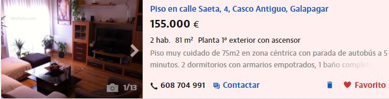

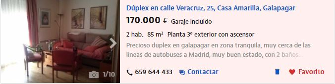

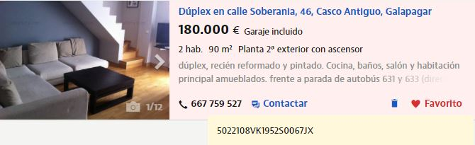

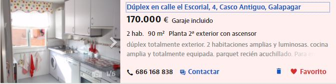

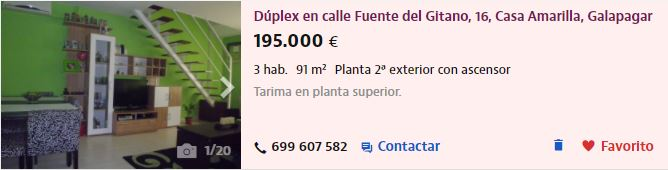

[figure not shown]

#### **La fecha de la visita es del: domingo 19 diciembre 2021**

#### **La fecha del expediente es del: miércoles 29 diciembre 2021**

#### **La fecha del validez es del: martes 29 marzo 2022**

```
[1] "miércoles 29 diciembre 2021"
```

[figure not shown]

**Fdo: Francisco Javier Polo Martinez**

Arquitecto Tecnico  
COATTM 11285  
Master en Big Data y Business Analytic  
Data Scientist

**REFERENCIAS EXTERNAS**

Wikipedia: [enlace a Wikipedia](https://upload.wikimedia.org/wikipedia/es/timeline/d7d70da8b2f6bb2903cf0b930fc55d48.png)

Planeamiento obtenido del link de la Comunidad de Madrid: [enlace a Planeamiento de la CAM](http://www.madrid.org/cartografia/planea/planeamiento/html/visor.htm)

Instituto Nacional de Estadistica: [enlace al Instituto Nacional de Estadistica:](https://www.ine.es/)

```r
save.image(file="C:/Users/polo/Desktop/AEVIU/0002/0002pisoV06----BLOCKQUOTE.RData")
```